# 05: phyloseq

## Plotting phyloseq objects

One very useful aspect of `phyloseq` is its analysis and plotting capacity. Although you could make any plot you want with the two data sets and some time spent with `dplyr` and `ggplot`, `phyloseq` makes this process more convenient for you.

Imagine we want to look into alpha diversity for our data.

```r
# estimate several types of alpha diversity
estimate_richness(phylo_obj)
```

```
##         Observed     Chao1  se.chao1       ACE   se.ACE  Shannon   Simpson
## JPA_Jan       77  78.42857  1.934109  80.02564 4.006838 2.328218 0.8264015
## JPA_Feb      129 139.05882  6.176716 140.52846 5.774252 2.798927 0.8952575
## JPA_May       87  93.00000  4.698735  93.99543 4.744762 3.111995 0.9039400
## JPA_Jun       74  85.14286  8.229580  82.36503 4.417699 2.196396 0.8287407
## LOP_Jan       78  87.00000  8.043457  82.28375 4.464933 2.223889 0.8233873
## LOP_Feb      100 107.20000  6.438425 104.27497 4.954386 2.299640 0.7968385
## LOP_Jun       82  88.00000  5.387736  86.67303 4.614734 1.852421 0.5897740
## LOP_Jul       83  88.60000  5.345652  86.84282 4.493433 3.243153 0.9301463
## MBL_Jan      124 166.50000 19.358115 155.95675 6.233127 2.174337 0.7695153
## MBL_Feb      152 171.77273  9.521684 177.88873 6.704856 2.412068 0.8330976
## MBL_Jun      106 111.20000  3.988082 118.53728 5.320353 2.860147 0.8825670
## MBL_Aug      110 121.14286  8.230927 122.98751 5.044153 3.394681 0.9471395
##         InvSimpson    Fisher
## JPA_Jan   5.760418 10.043150
## JPA_Feb   9.547219 19.543810
## JPA_May  10.410165 17.150894
## JPA_Jun   5.839099  9.779846
## LOP_Jan   5.662109 11.151621
## LOP_Feb   4.922192 13.969593
## LOP_Jun   2.437680 12.527189
## LOP_Jul  14.315643 14.555274
## MBL_Jan   4.338683 19.929909
## MBL_Feb   5.991525 21.165852
## MBL_Jun   8.515493 15.320310
## MBL_Aug  18.917713 16.983280
```

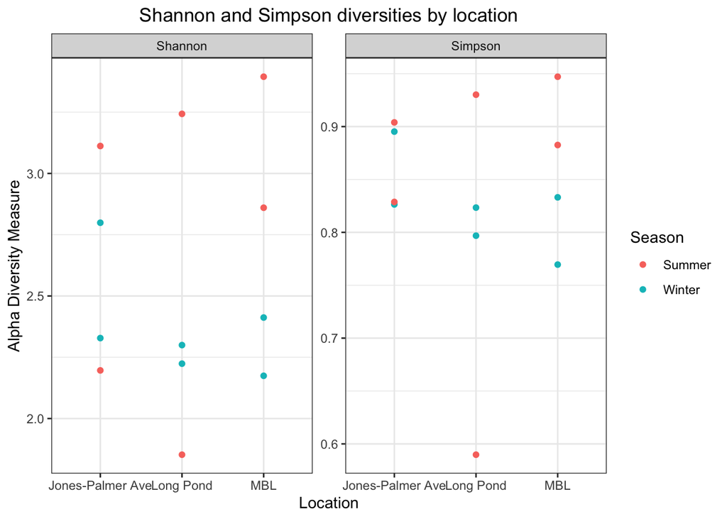

```r
# plot Shannon and Simpson diversity measures by location
# note: this plotting function is a wrapper for ggplot, so we can customize it as we would a ggplot object
plot_richness(phylo_obj, x = "Location", color = "Season", measures = c("Shannon", "Simpson")) +
  # use a black and white background
  theme_bw() +
  # add a title
  ggtitle("Shannon and Simpson diversities by location") +
  # center the title
  theme(plot.title = element_text(hjust = 0.5))
```

Now imagine we want to make an ordination plot where we compare communities based on Bray-Curtis dissimilarities.

```r
# calculate bray-curtis dissimilarities between each sample
# then perform dimension reduction with nMDS (non-metric Multi Dimensional Scaling)
phylo_bray <- ordinate(phylo_obj, "NMDS", "bray")
```

```
## Square root transformation
## Wisconsin double standardization
## *** Best solution repeated 3 times
```

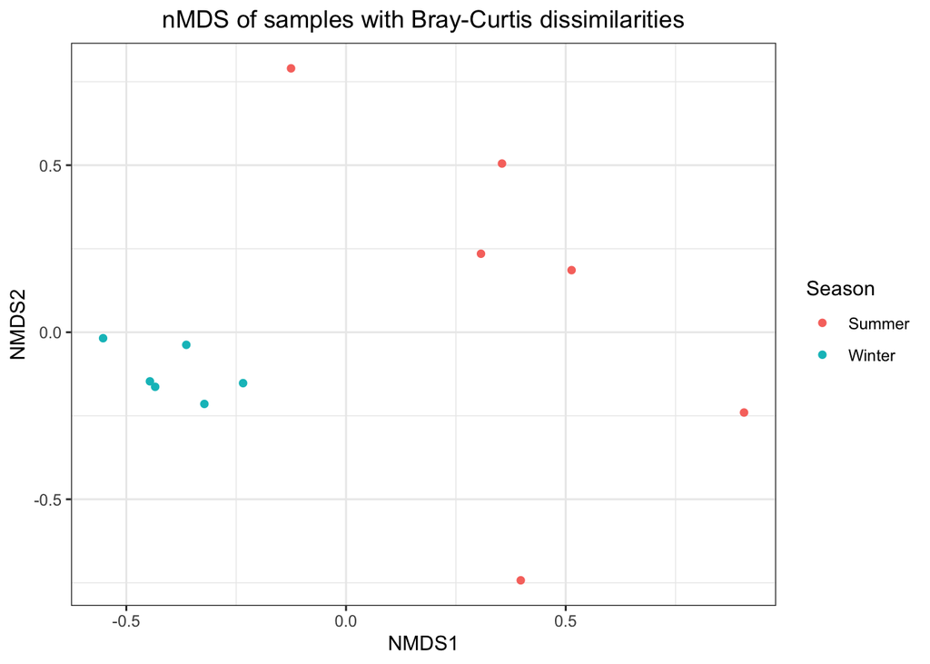

```r
# color our plot by season
plot_ordination(phylo_obj, phylo_bray, type="samples", color="Season") +
  # use a black and white background
  theme_bw() +
  # add a title
  ggtitle("nMDS of samples with Bray-Curtis dissimilarities") +
  # center the title
  theme(plot.title = element_text(hjust = 0.5))
```

## Getting data out of phyloseq

Finally, there are some settings where you might rather work with individual data tables than with your phyloseq object. Pretend for a moment that you started with your `phylo_obj` object and have no access to the `covariates` or `abundances` data frames. `phyloseq` has handy functions for us to extract each of its three tables.

```r
# extract sample data table
samp_tab <- sample_data(phylo_obj)
head(samp_tab)
```

```
##                 Location Month Season      Type
## JPA_Jan Jones-Palmer Ave   Jan Winter   Outfall
## JPA_Feb Jones-Palmer Ave   Feb Winter   Outfall
## JPA_May Jones-Palmer Ave   May Summer   Outfall
## JPA_Jun Jones-Palmer Ave   Jun Summer   Outfall
## LOP_Jan        Long Pond   Jan Winter Reservoir
## LOP_Feb        Long Pond   Feb Winter Reservoir
```

```r
# extract otu table
otu_tab <- otu_table(phylo_obj)
head(otu_tab)
```

```
## OTU Table:          [6 taxa and 12 samples]
##                      taxa are rows
##       JPA_Jan JPA_Feb JPA_May JPA_Jun LOP_Jan LOP_Feb LOP_Jun LOP_Jul MBL_Jan
## taxa1       0       0       0       0       0       0       0       0       0
## taxa2       0       2       0       0       0       0       0       0       0
## taxa3       0       5       0       0       4       0       0       0       0
## taxa4       0       0       0       0       0       0       0       0       0
## taxa5      27       0       0       0       0      17       0       0       3
## taxa6       0       0       0       0       0       0       0       0       0
##       MBL_Feb MBL_Jun MBL_Aug
## taxa1       3       0       0
## taxa2       0       0       0
## taxa3       4       0       6
## taxa4       0       0      10
## taxa5      13       0       0
## taxa6       0       0       1
```

```r
# extract taxonomy table
taxon_tab <- tax_table(phylo_obj)
head(taxon_tab)
```

```
## Taxonomy Table:     [6 taxa by 6 taxonomic ranks]:
##       kingdom    phylum          class                order
## taxa1 "Bacteria" "Acidobacteria" "Acidobacteria"      "Acidobacteriales"
## taxa2 "Bacteria" "Acidobacteria" "Acidobacteria"      "Acidobacteriales"
## taxa3 "Bacteria" "Acidobacteria" "Acidobacteria"      "Acidobacteriales"
## taxa4 "Bacteria" "Acidobacteria" "Acidobacteria_Gp22" "Unassigned"
## taxa5 "Bacteria" "Acidobacteria" "Holophagae"         "Holophagales"
## taxa6 "Bacteria" "Acidobacteria" "Holophagae"         "orderx_NA"
##       family              genus
## taxa1 "Acidobacteriaceae" "Edaphobacter"
## taxa2 "Acidobacteriaceae" "Solibacter"
## taxa3 "Acidobacteriaceae" "genus_NA"
## taxa4 "Unassigned"        "Gp22"
## taxa5 "Holophagaceae"     "Geothrix"
## taxa6 "family_NA"         "genus_NA"
```

Now you have each of these tables as their own R objects and can manipulate and analyze them however you would like!

## Exercise

Using the `phylo_obj` object, subset to only taxa that belong to *Firmicutes*. Build an ordination plot based on the subsetted `phyloseq` object you’ve created using Bray-Curtis dissimilarities and nMDS (as in the above section) and color the points by the location where they were collected.

*Hint*: subset to a specific taxa with `subset_taxa()`.

*Hint*: locations are saved as the “Location” variable in the `covariates` dataset.

## References

```r
citation("phyloseq")
```

```
##
##
##   phyloseq: An R package for reproducible interactive analysis and
##   graphics of microbiome census data. Paul J. McMurdie and Susan Holmes
##   (2013) PLoS ONE 8(4):e61217.
##
## A BibTeX entry for LaTeX users is
##
##   @Article{,
##     author = {Paul J. McMurdie and Susan Holmes},
##     journal = {PLoS ONE},
##     pages = {e61217},
##     title = {phyloseq: An R package for reproducible interactive analysis and graphics of microbiome census data},
##     volume = {8},
##     number = {4},
##     year = {2013},
##     url = {http://dx.plos.org/10.1371/journal.pone.0061217},
##   }
```

Some materials adapted from this [tutorial](https://www.nicholas-ollberding.com/post/introduction-to-phyloseq/) by Nicholas Ollberding.